# Reproducible Research: Assignment 1

Daniel Thornton

10/07/2018

This document processes and describes data taken from personal movement using activity monitoring devices

## Setup

Set default options and install the right libraries

```r
knitr::opts_chunk$set(echo = TRUE)
library(lattice)
```

## Load data

Read in the data and include the necessary libraries, assuming the activity.zip exists in the current working directory

```r
library(lattice)

fileUrl <- "https://d396qusza40orc.cloudfront.net/repdata%2Fdata%2Factivity.zip"
download.file(fileUrl,destfile = paste0(getwd(), '/activity.zip'), method = "curl")
unzip("activity.zip",exdir = "data")
data <- read.csv("activity.csv")
```

## Daily activity

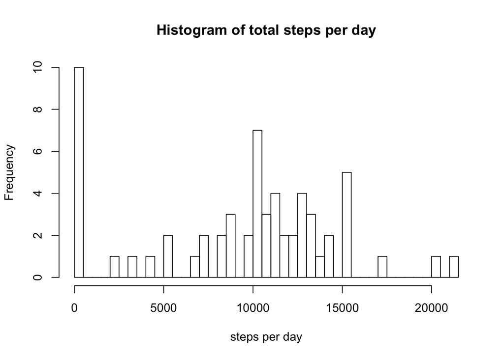

```r
# Histogram of the steps per day
steps_per_day <- aggregate(data[, c('steps')], list(data$date), FUN = function(x) sum(x, na.rm = TRUE))
colnames(steps_per_day) <- c('Date','Steps')
hist(steps_per_day$Steps, xlab="steps per day", breaks=40, main="Histogram of total steps per day")
```

```r
mean_steps_per_day <- mean(steps_per_day$Steps)
median_steps_per_day <- median(steps_per_day$Steps)
```

Mean steps in the data per day: 9354.2295082

Median steps in the data per day: 10395

## Interval activity

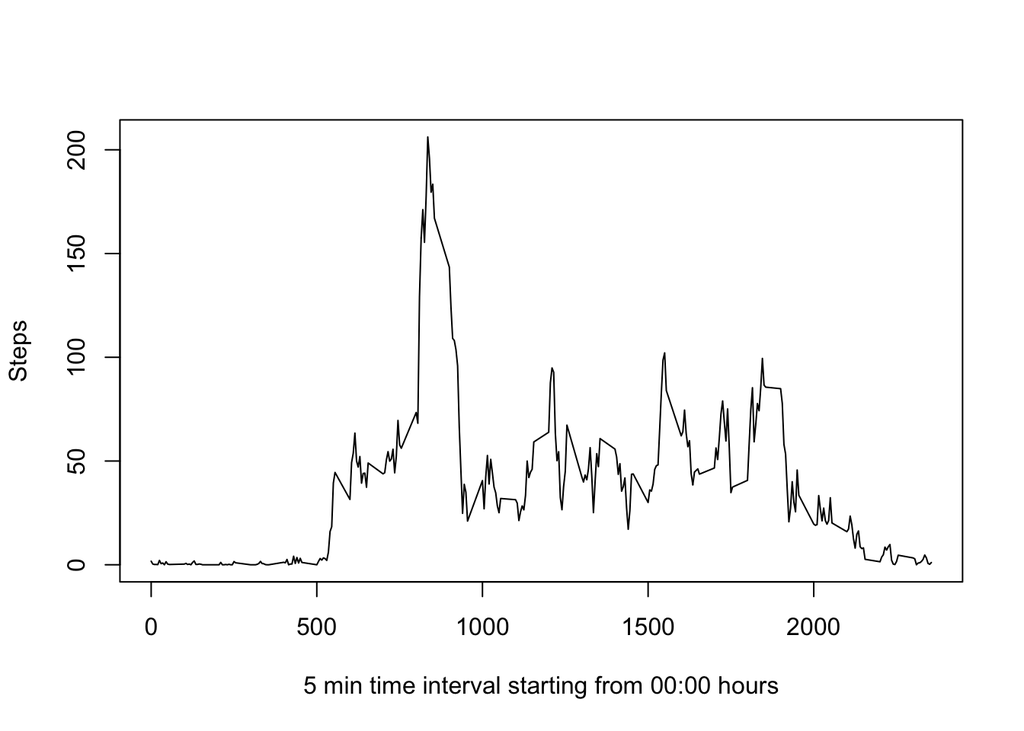

```r
# Time series of steps per 5 minute window, averaged across all days
steps_per_window <- aggregate(data[, c('steps')], list(data$interval), FUN = function(x) mean(x, na.rm = TRUE))
colnames(steps_per_window) <- c('interval','mean_steps')

interval_with_most_steps <- steps_per_window[steps_per_window$mean_steps == max(steps_per_window$mean_steps),]$interval

plot(steps_per_window, type="l", xlab="5 min time interval starting from 00:00 hours", ylab="Steps")
```

The interval with the largest mean number of steps is interval no. 835

## Finding and imputating missing values

```r
# How many rows with NAs in the original data
rows_with_missing_data <- nrow(data[!complete.cases(data), ])
```

There are 2304 rows with missing values for the step count.

To patch the missing values, the average for that time interval taken from the other days is used, recorded in the steps_per_window variable, and joined onto the original data.

```r
# Patch up the rows with missing data and plot a histogram of the new data

rows_with_missing_data <- data[!complete.cases(data$steps), ]
rows_without_missing_data <- data[complete.cases(data$steps), ]

rows_with_missing_data <- merge(rows_with_missing_data, steps_per_window, by.x="interval", by.y="interval")
rows_with_missing_data$steps <- as.integer(round(rows_with_missing_data$mean_steps))
rows_with_missing_data <- rows_with_missing_data[,c(1:3)]

new_data <- rbind(rows_with_missing_data, rows_without_missing_data)
new_data <- new_data[order(new_data$date,new_data$interval),]
```

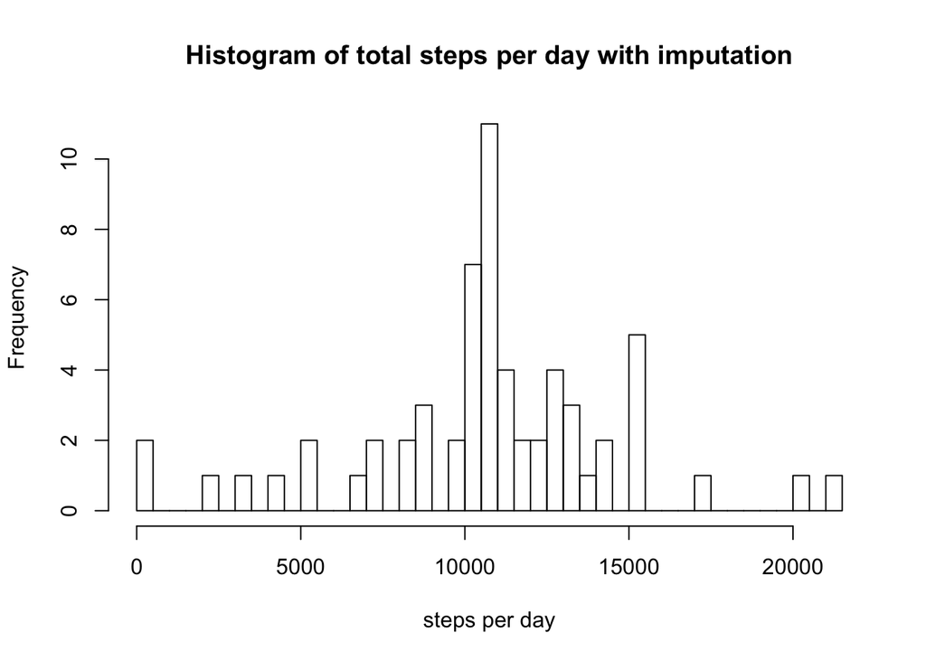

```r
# Plot steps per day using the new imputed data
steps_per_day_new <- aggregate(new_data[, c('steps')], list(new_data$date), FUN = function(x) sum(x, na.rm = TRUE))
colnames(steps_per_day_new) <- c('date','steps')
hist(steps_per_day_new$steps, xlab="steps per day", breaks=40, main="Histogram of total steps per day with imputation")
```

```r
# Check the mean and median of the new imputed data
new_total_steps <- sum(steps_per_day_new$steps, na.rm=TRUE)
new_mean_steps <- mean(steps_per_day_new$steps, na.rm=TRUE)
new_median_steps <- median(steps_per_day_new$steps, na.rm=TRUE)
```

[output not shown]

After imputing missing values where the data on step count was missing:

The median number of steps is: 10762

## Compare weekday and weekend activity

Plot the comparison of weekend activity to weekday activity, based on 5 minute windows of activity recording.

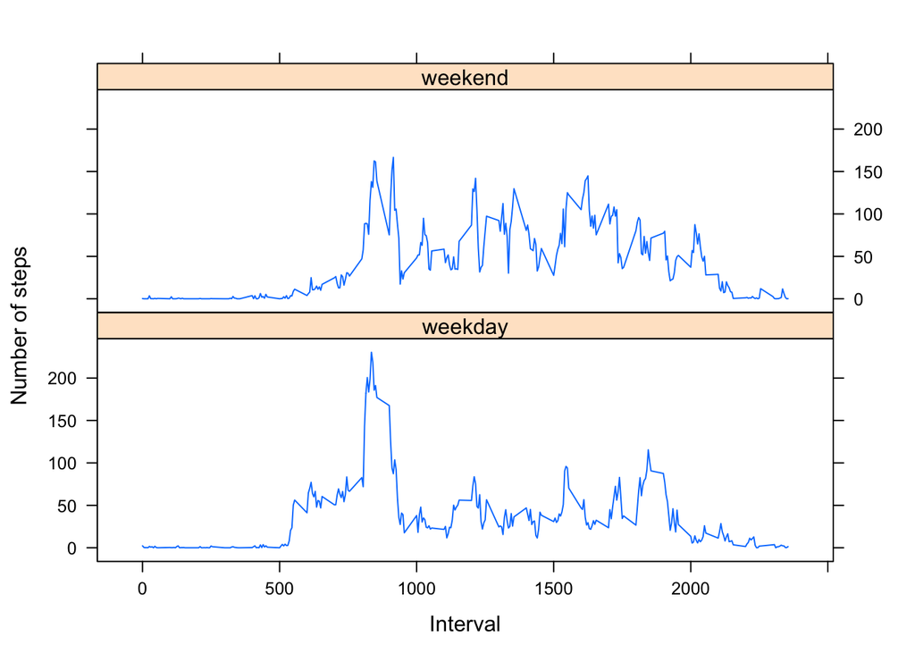

```r
# Use a factor for the day of week

new_data$day <- weekdays(as.Date(new_data$date))
weekends <- new_data[new_data$day %in% c('Saturday','Sunday'),]
weekends$day <- factor('weekend')
weekdays <- new_data[new_data$day %in% c('Monday','Tuesday','Wednesday','Thursday','Friday'),]
weekdays$day <- factor('weekday')
new_data_new <- rbind(weekends,weekdays)

weekdays_steps_per_day <- aggregate(weekdays[, c('steps')], list(weekdays$interval), FUN = function(x) mean(x, na.rm = TRUE))
colnames(weekdays_steps_per_day) <- c('interval','mean_steps')
weekdays_steps_per_day$day_type <- c('weekday')

weekend_steps_per_day <- aggregate(weekends[, c('steps')], list(weekends$interval), FUN = function(x) mean(x, na.rm = TRUE))
colnames(weekend_steps_per_day) <- c('interval','mean_steps')
weekend_steps_per_day$day_type <- c('weekend')

by_day_type <- rbind(weekdays_steps_per_day, weekend_steps_per_day)

xyplot(by_day_type$mean_steps~by_day_type$interval | by_day_type$day_type, xlab="Interval", ylab="Number of steps",layout=c(1,2), type="l", title="Plot of the number of steps per 5 minute window comparing weekend to weekdays.")
```